# CBS Social Survey Report

Version 08

Author

Saar Alon-Barkat, University of Haifa

Published

January 13, 2023

```r
library(tidyverse)
library(gt)
library(gtsummary)
library(janitor)
library(sjPlot)
library(ggcorrplot)
Sys.setlocale("LC_ALL","Herbrew")
```

```
[1] ""
```

This report summarizes first results from Israel CBS social surveys in years 2015-2021, focused on trust in government and trust in the judicary system.

**This is a preliminary report, reflecting work in progress. Please contact author before citing.**

Raw data obtained from the Israel CBS website: https://www.cbs.gov.il/he/subjects/Pages/%D7%94%D7%A1%D7%A7%D7%A8-%D7%94%D7%97%D7%91%D7%A8%D7%AA%D7%99.aspx

The data is analyzed and used in accordance with PUF license.

Information on the social survey available online at the Israel CBS website.

R code available at GitHub: https://github.com/saaralonbarkat/IL_CBS_social_survey

Statistical notes:

# **The data**

```r
lss_2015_raw<-read_csv("data/H20151311data.csv",na=c(NA,"999999","888888"))
lss_2016_raw<-read_csv("data/H20161342data.csv",na=c(NA,"999999","888888"))
lss_2017_raw<-read_csv("data/H20171353data.csv",na=c(NA,"999999","888888"))
lss_2018_raw<-read_csv("data/H20181362data.csv",na=c(NA,"999999","888888"))
lss_2019_raw<-read_csv("data/H20191424data.csv",na=c(NA,"999999","888888"))
lss_2020_raw<-read_csv("data/H20201453data.csv",na=c(NA,"999999","888888"))
lss_2021_raw<-read_csv("data/H20211461data.csv",na=c(NA,"999999","888888"))
```

```r
lss_total <- bind_rows(lss_2015_raw %>% janitor::clean_names(),
                       lss_2016_raw %>% janitor::clean_names(),
                       lss_2017_raw %>% janitor::clean_names(),
                       lss_2018_raw %>% janitor::clean_names(),
                       lss_2019_raw %>% janitor::clean_names(),
                       lss_2020_raw %>% janitor::clean_names(),
                       lss_2021_raw %>% janitor::clean_names()) %>%
  mutate(
    district = recode(
      machoz,
      `1` = "jerusalem",
      `2` = "north",
      `3` = "haifa",
      `4` = "center",
      `5` = "tel_aviv",
      `6` = "south",
      `7` = "yosh"
    ),
    subdistrict = nafa,
    residense_type = zurat_yishuv,
    religion = recode(
      dat,
      `1` = "1. jewish",
      `2` = "2. muslim",
      `3` = "3. christian",
      `4` = "4. druze",
      `5` = "5. other",
      `6` = "6. no_religion"
    ),
    year = recode(
      shana,
      `15` = 2015,
      `16` = 2016,
      `17` = 2017,
      `18` = 2018,
      `19` = 2019,
      `20` = 2020,
      `21` = 2021
    ) %>% replace_na(2016),
    performance_health = recode(
      tifkud_briut,
      `1` = 4,
      `2` = 3,
      `3` = 2,
      `4` = 1
    ),
    trust_in_gov = recode(
      emun_memshala,
      `1` = 4,
      `2` = 3,
      `3` = 2,
      `4` = 1
    ),
    trust_healthcare = recode(
      emun_briut,
      `1` = 4,
      `2` = 3,
      `3` = 2,
      `4` = 1
    ),
    trust_healthcare_bi = recode(
      emun_briut,
      `1` = 1,
      `2` = 1,
      `3` = 0,
      `4` = 0
    ),
    performance_health_bi = recode(
      tifkud_briut,
      `1` = 1,
      `2` = 1,
      `3` = 0,
      `4` = 0
    ),
    trust_in_gov_bi = recode(
      emun_memshala,
      `1` = 1,
      `2` = 1,
      `3` = 0,
      `4` = 0
    ),
    performance_education = recode(
      tifkud_hinuch,
      `1` = 4,
      `2` = 3,
      `3` = 2,
      `4` = 1
    ),
    performance_education_bi = recode(
      tifkud_hinuch,
      `1` = 1,
      `2` = 1,
      `3` = 0,
      `4` = 0
    ),
    trust_in_police = recode(
      emun_mishtara,
      `1` = 4,
      `2` = 3,
      `3` = 2,
      `4` = 1
    ),
    trust_in_police_bi = recode(
      emun_mishtara,
      `1` = 1,
      `2` = 1,
      `3` = 0,
      `4` = 0
    ),
    performance_police = recode(
      tifkud_mishtara,
      `1` = 4,
      `2` = 3,
      `3` = 2,
      `4` = 1
    ),
    performance_police_bi = recode(
      tifkud_mishtara,
      `1` = 1,
      `2` = 1,
      `3` = 0,
      `4` = 0
    ),
    performance_municipality = recode(
      tifkud_iriya,
      `1` = 4,
      `2` = 3,
      `3` = 2,
      `4` = 1
    ),
    performance_municipality_bi = recode(
      tifkud_iriya,
      `1` = 1,
      `2` = 1,
      `3` = 0,
      `4` = 0
    ),
    trust_in_knesset = recode(
      emun_kneset,
      `1` = 4,
      `2` = 3,
      `3` = 2,
      `4` = 1
    ),
    trust_in_knesset_bi = recode(
      emun_kneset,
      `1` = 1,
      `2` = 1,
      `3` = 0,
      `4` = 0
    ),
    performance_knesset = recode(
      tifkud_kneset,
      `1` = 4,
      `2` = 3,
      `3` = 2,
      `4` = 1
    ),
    performance_knesset_bi = recode(
      tifkud_kneset,
      `1` = 1,
      `2` = 1,
      `3` = 0,
      `4` = 0
    ),
    trust_in_judiciary = recode(
      emun_mishpat,
      `1` = 4,
      `2` = 3,
      `3` = 2,
      `4` = 1
    ),
    trust_in_judiciary_bi = recode(
      emun_mishpat,
      `1` = 1,
      `2` = 1,
      `3` = 0,
      `4` = 0
    ),
    trust_in_army = recode(
      emun_tzahal,
      `1` = 4,
      `2` = 3,
      `3` = 2,
      `4` = 1
    ),
    trust_in_army_bi = recode(
      emun_tzahal,
      `1` = 1,
      `2` = 1,
      `3` = 0,
      `4` = 0
    ),
    trust_in_comptroller = recode(
      emun_mevaker,
      `1` = 4,
      `2` = 3,
      `3` = 2,
      `4` = 1
    ),
    trust_in_comptroller_bi = recode(
      emun_mevaker,
      `1` = 1,
      `2` = 1,
      `3` = 0,
      `4` = 0
    ),
    satisfied_area = recode(
      merutze_ezor,
      `1` = 4,
      `2` = 3,
      `3` = 2,
      `4` = 1
    ),
    satisfied_area_bi = recode(
      merutze_ezor,
      `1` = 1,
      `2` = 1,
      `3` = 0,
      `4` = 0
    ),
    satisfied_transport = recode(
      merutze_tachbura,
      `1` = 4,
      `2` = 3,
      `3` = 2,
      `4` = 1
    ),
    satisfied_transport_bi = recode(
      merutze_tachbura,
      `1` = 1,
      `2` = 1,
      `3` = 0,
      `4` = 0
    ),
    satisfied_parks = recode(
      merutze_ezor_parkim,
      `1` = 4,
      `2` = 3,
      `3` = 2,
      `4` = 1
    ),
    satisfied_parks_bi = recode(
      merutze_ezor_parkim,
      `1` = 1,
      `2` = 1,
      `3` = 0,
      `4` = 0
    ),
    satisfied_clean = recode(
      merutze_ezor_nikayon,
      `1` = 4,
      `2` = 3,
      `3` = 2,
      `4` = 1
    ),
    satisfied_clean_bi = recode(
      merutze_ezor_nikayon,
      `1` = 1,
      `2` = 1,
      `3` = 0,
      `4` = 0
    ),
    satisfied_trash = recode(
      merutze_ezor_ashpa,
      `1` = 4,
      `2` = 3,
      `3` = 2,
      `4` = 1
    ),
    satisfied_trash_bi = recode(
      merutze_ezor_ashpa,
      `1` = 1,
      `2` = 1,
      `3` = 0,
      `4` = 0
    ),
    satisfied_roads = recode(
      merutze_kvishim,
      `1` = 4,
      `2` = 3,
      `3` = 2,
      `4` = 1
    ),
    satisfied_roads_bi = recode(
      merutze_kvishim,
      `1` = 1,
      `2` = 1,
      `3` = 0,
      `4` = 0
    ),
    religiosity_level_jews = case_when(
      datiut_yehudi==1 ~ "1. Haredi",
      datiut_yehudi==2 ~ "2. Dati",
      datiut_yehudi==3 ~ "3. Masorty dati",
      datiut_yehudi==4 ~ "4. Masorty lo col cah dati",
      datiut_yehudi==5 ~ "5. Hilony",
      datiut_yehudi %in% NA & pop_group==1 ~ "Other (non Arab)"),
    feel_safe = recode(
      margish_batuach,
      `1` = 4,
      `2` = 3,
      `3` = 2,
      `4` = 1
      ) %>% na_if(5),
    feel_safe_bi = recode(
      margish_batuach,
      `1` = 1,
      `2` = 1,
      `3` = 0,
      `4` = 0
    ) %>% na_if(5),
    reside_own_apartment = recode(
      dira_baalut,
      `1` = 1,
      `2` = 0
      ),
    own_apartment = recode(
      dira_baalut_c,
      `1` = 1,
      `2` = 0
      ),
    arab = ifelse(pop_group == 2, 1, 0),
    ultra_orthodox = ifelse(datiut_yehudi == 1, 1, 0),
    russian_ole = ifelse(yelid_brham == 1, 1, 0)) %>%
  mutate(mizrahi_origin = ifelse(
      arab == 0 &
        (
          semel_eretz %in% c(3, 4) |
            semel_eretz_av_c %in% c(3, 4) | semel_eretz_em_c %in% c(3, 4)
        ),
      1,
      0
    ),
    gender = recode(minn, `1` = "male", `2` = "female"),
    age = recode(
      gil,
      `1` = "20-24",
      `2` = "25-29",
      `3` = "30-34",
      `4` = "34-39",
      `5` = "40-44",
      `6` = "45-49",
      `7` = "50-54",
      `8` = "55-59",
      `9` = "60-64",
      `10` = "65-74",
      `11` = "75_plus"
    ),
    household_income = recode(
      hachnasa_kolelet_neto,
      `1` = "1. 0-2500",
      `2` = "2. 2500-4000",
      `3` = "3. 4000-5000",
      `4` = "4. 5000-6500",
      `5` = "5. 6500-8000",
      `6` = "6. 8000-10000",
      `7` = "7. 10000-13000",
      `8` = "8. 13000-17000",
      `9` = "9. 17000-24000",
      `10` = "10. 24000+",
      `11` = "11. no_income"
    )) %>%
  mutate(
    sector = case_when(
      arab == 1 ~ "arab",
      ultra_orthodox == 1 ~ "ultra_orthodox",
      TRUE ~ "general"
    ))
```

```r
lss_total%>%
  group_by(year)%>%
  summarize(n_participants=n())%>%
  gt()
```

| year | n_participants |
| --- | --- |
| 2015 | 7078 |
| 2016 | 7048 |
| 2017 | 7230 |
| 2018 | 7448 |
| 2019 | 7575 |
| 2020 | 7249 |
| 2021 | 7416 |

```r
lss_total%>%
  select(year,
         gender,
         sector,
         religion,
         religiosity_level_jews,
         age,
         district,
         subdistrict,
         household_income,
         russian_ole,
         trust_in_gov,
         trust_in_gov_bi,
         trust_in_judiciary,
         trust_in_judiciary_bi)%>%
  glimpse()
```

```
Rows: 51,044
Columns: 14
$ year                   <dbl> 2015, 2015, 2015, 2015, 2015, 2015, 2015, 2015,…
$ gender                 <chr> "female", "male", "male", "female", "female", "…
$ sector                 <chr> "general", "general", "arab", "arab", "ultra_or…
$ religion               <chr> "1. jewish", "1. jewish", "2. muslim", "3. chri…
$ religiosity_level_jews <chr> "5. Hilony", "4. Masorty lo col cah dati", NA, …
$ age                    <chr> "34-39", "50-54", "34-39", "45-49", "20-24", "3…
$ district               <chr> "haifa", "haifa", "north", "north", "tel_aviv",…
$ subdistrict            <dbl> 31, 31, 24, 23, 51, 51, 62, 42, 24, 11, 51, 21,…
$ household_income       <chr> "7. 10000-13000", "6. 8000-10000", "3. 4000-500…
$ russian_ole            <dbl> 0, 0, 0, 0, 0, 0, 0, 0, 1, 0, 0, 0, 0, 0, 1, 0,…
$ trust_in_gov           <dbl> 2, 3, NA, NA, NA, 3, 4, 2, 3, 1, 1, 2, 1, 2, 3,…
$ trust_in_gov_bi        <dbl> 0, 1, NA, NA, NA, 1, 1, 0, 1, 0, 0, 0, 0, 0, 1,…
$ trust_in_judiciary     <dbl> 2, 1, 3, 2, NA, 3, 4, NA, NA, NA, 4, 1, 1, 2, 3…
$ trust_in_judiciary_bi  <dbl> 0, 0, 1, 0, NA, 1, 1, NA, NA, NA, 1, 0, 0, 0, 1…
```

```r
lss_total%>%
  select(year,
         gender,
         sector,
         religion,
         religiosity_level_jews,
         age,
         district,
         subdistrict,
         household_income,
         russian_ole,
         trust_in_gov,
         trust_in_gov_bi,
         trust_in_judiciary,
         trust_in_judiciary_bi)%>%  tbl_summary()
```

| **Characteristic** | **N = 51,044**<sup>1</sup> |
| --- | --- |
| year |  |
| 2015 | 7,078 (14%) |
| 2016 | 7,048 (14%) |
| 2017 | 7,230 (14%) |
| 2018 | 7,448 (15%) |
| 2019 | 7,575 (15%) |
| 2020 | 7,249 (14%) |
| 2021 | 7,416 (15%) |
| gender |  |
| female | 25,985 (51%) |
| male | 25,059 (49%) |
| sector |  |
| arab | 9,274 (18%) |
| general | 37,717 (74%) |
| ultra_orthodox | 4,053 (7.9%) |
| religion |  |
| 1. jewish | 39,593 (78%) |
| 2. muslim | 7,450 (15%) |
| 3. christian | 1,613 (3.2%) |
| 4. druze | 955 (1.9%) |
| 5. other | 114 (0.2%) |
| 6. no_religion | 1,259 (2.5%) |
| Unknown | 60 |
| religiosity_level_jews |  |
| 1. Haredi | 4,053 (9.7%) |
| 2. Dati | 4,358 (10%) |
| 3. Masorty dati | 4,916 (12%) |
| 4. Masorty lo col cah dati | 8,473 (20%) |
| 5. Hilony | 17,632 (42%) |
| Other (non Arab) | 2,338 (5.6%) |

[output cut: 52 more lines]

<sup>1</sup> n (%); Median (IQR)

```r
lss_total%>%
  select(year,
         gender,
         sector,
         religion,
         religiosity_level_jews,
         age,
         district,
         subdistrict,
         household_income,
         russian_ole,
         trust_in_gov,
         trust_in_gov_bi,
         trust_in_judiciary,
         trust_in_judiciary_bi)%>%
  tbl_summary(by=year)
```

| **Characteristic** | **2015**, N = 7,078<sup>1</sup> | **2016**, N = 7,048<sup>1</sup> | **2017**, N = 7,230<sup>1</sup> | **2018**, N = 7,448<sup>1</sup> | **2019**, N = 7,575<sup>1</sup> | **2020**, N = 7,249<sup>1</sup> | **2021**, N = 7,416<sup>1</sup> |
| --- | --- | --- | --- | --- | --- | --- | --- |
| gender |  |  |  |  |  |  |  |
| female | 3,605 (51%) | 3,680 (52%) | 3,670 (51%) | 3,766 (51%) | 3,824 (50%) | 3,647 (50%) | 3,793 (51%) |
| male | 3,473 (49%) | 3,368 (48%) | 3,560 (49%) | 3,682 (49%) | 3,751 (50%) | 3,602 (50%) | 3,623 (49%) |
| sector |  |  |  |  |  |  |  |
| arab | 1,261 (18%) | 1,342 (19%) | 1,350 (19%) | 1,287 (17%) | 1,397 (18%) | 1,216 (17%) | 1,421 (19%) |
| general | 5,290 (75%) | 5,141 (73%) | 5,291 (73%) | 5,598 (75%) | 5,576 (74%) | 5,443 (75%) | 5,378 (73%) |
| ultra_orthodox | 527 (7.4%) | 565 (8.0%) | 589 (8.1%) | 563 (7.6%) | 602 (7.9%) | 590 (8.1%) | 617 (8.3%) |
| religion |  |  |  |  |  |  |  |
| 1. jewish | 5,500 (78%) | 5,394 (77%) | 5,586 (77%) | 5,838 (79%) | 5,871 (78%) | 5,730 (79%) | 5,674 (77%) |
| 2. muslim | 979 (14%) | 1,126 (16%) | 1,072 (15%) | 1,041 (14%) | 1,123 (15%) | 978 (14%) | 1,131 (15%) |
| 3. christian | 247 (3.5%) | 209 (3.0%) | 243 (3.4%) | 233 (3.1%) | 225 (3.0%) | 213 (2.9%) | 243 (3.3%) |
| 4. druze | 168 (2.4%) | 123 (1.7%) | 145 (2.0%) | 106 (1.4%) | 153 (2.0%) | 122 (1.7%) | 138 (1.9%) |
| 5. other | 16 (0.2%) | 15 (0.2%) | 20 (0.3%) | 17 (0.2%) | 14 (0.2%) | 17 (0.2%) | 15 (0.2%) |
| 6. no_religion | 164 (2.3%) | 174 (2.5%) | 159 (2.2%) | 199 (2.7%) | 179 (2.4%) | 182 (2.5%) | 202 (2.7%) |
| Unknown | 4 | 7 | 5 | 14 | 10 | 7 | 13 |
| religiosity_level_jews |  |  |  |  |  |  |  |
| 1. Haredi | 527 (9.1%) | 565 (9.9%) | 589 (10%) | 563 (9.1%) | 602 (9.7%) | 590 (9.8%) | 617 (10%) |
| 2. Dati | 580 (10.0%) | 585 (10%) | 620 (11%) | 640 (10%) | 657 (11%) | 664 (11%) | 612 (10%) |
| 3. Masorty dati | 631 (11%) | 652 (11%) | 662 (11%) | 744 (12%) | 761 (12%) | 706 (12%) | 760 (13%) |
| 4. Masorty lo col cah dati | 1,307 (22%) | 1,187 (21%) | 1,181 (20%) | 1,289 (21%) | 1,286 (21%) | 1,145 (19%) | 1,078 (18%) |
| 5. Hilony | 2,434 (42%) | 2,389 (42%) | 2,507 (43%) | 2,579 (42%) | 2,551 (41%) | 2,593 (43%) | 2,579 (43%) |
| Other (non Arab) | 338 (5.8%) | 328 (5.7%) | 321 (5.5%) | 346 (5.6%) | 321 (5.2%) | 335 (5.6%) | 349 (5.8%) |
| Unknown | 1,261 | 1,342 | 1,350 | 1,287 | 1,397 | 1,216 | 1,421 |
| age |  |  |  |  |  |  |  |
| 20-24 | 765 (11%) | 746 (11%) | 769 (11%) | 829 (11%) | 801 (11%) | 772 (11%) | 799 (11%) |
| 25-29 | 785 (11%) | 710 (10%) | 739 (10%) | 740 (9.9%) | 806 (11%) | 805 (11%) | 823 (11%) |
| 30-34 | 731 (10%) | 744 (11%) | 775 (11%) | 740 (9.9%) | 800 (11%) | 758 (10%) | 782 (11%) |
| 34-39 | 711 (10%) | 679 (9.6%) | 698 (9.7%) | 732 (9.8%) | 735 (9.7%) | 743 (10%) | 692 (9.3%) |
| 40-44 | 706 (10.0%) | 698 (9.9%) | 721 (10.0%) | 710 (9.5%) | 735 (9.7%) | 716 (9.9%) | 695 (9.4%) |
| 45-49 | 554 (7.8%) | 620 (8.8%) | 633 (8.8%) | 665 (8.9%) | 656 (8.7%) | 649 (9.0%) | 669 (9.0%) |
| 50-54 | 536 (7.6%) | 524 (7.4%) | 522 (7.2%) | 531 (7.1%) | 563 (7.4%) | 548 (7.6%) | 585 (7.9%) |
| 55-59 | 529 (7.5%) | 489 (6.9%) | 521 (7.2%) | 551 (7.4%) | 486 (6.4%) | 512 (7.1%) | 486 (6.6%) |
| 60-64 | 511 (7.2%) | 498 (7.1%) | 487 (6.7%) | 501 (6.7%) | 516 (6.8%) | 419 (5.8%) | 448 (6.0%) |
| 65-74 | 691 (9.8%) | 768 (11%) | 785 (11%) | 839 (11%) | 885 (12%) | 821 (11%) | 838 (11%) |
| 75_plus | 559 (7.9%) | 572 (8.1%) | 580 (8.0%) | 610 (8.2%) | 592 (7.8%) | 506 (7.0%) | 599 (8.1%) |
| district |  |  |  |  |  |  |  |
| center | 1,750 (25%) | 1,678 (24%) | 1,808 (25%) | 1,977 (27%) | 1,951 (26%) | 1,787 (25%) | 1,843 (25%) |
| haifa | 940 (13%) | 876 (12%) | 958 (13%) | 896 (12%) | 968 (13%) | 822 (11%) | 894 (12%) |
| jerusalem | 712 (10%) | 824 (12%) | 781 (11%) | 815 (11%) | 854 (11%) | 902 (12%) | 884 (12%) |
| north | 1,276 (18%) | 1,267 (18%) | 1,259 (17%) | 1,266 (17%) | 1,317 (17%) | 1,216 (17%) | 1,255 (17%) |
| south | 996 (14%) | 905 (13%) | 880 (12%) | 915 (12%) | 935 (12%) | 961 (13%) | 1,013 (14%) |
| tel_aviv | 1,161 (16%) | 1,260 (18%) | 1,286 (18%) | 1,342 (18%) | 1,262 (17%) | 1,264 (17%) | 1,224 (17%) |
| yosh | 243 (3.4%) | 238 (3.4%) | 258 (3.6%) | 237 (3.2%) | 288 (3.8%) | 297 (4.1%) | 303 (4.1%) |
| subdistrict | 42 (24, 51) | 42 (24, 51) | 42 (24, 51) | 42 (24, 51) | 42 (24, 51) | 42 (24, 51) | 42 (24, 51) |
| household_income |  |  |  |  |  |  |  |
| 1. 0-2500 | 179 (3.2%) | 173 (3.0%) | 143 (2.5%) | 178 (2.9%) | 171 (2.8%) | 118 (2.3%) | 159 (2.9%) |
| 10. 24000+ | 446 (7.9%) | 499 (8.7%) | 539 (9.5%) | 658 (11%) | 777 (13%) | 649 (13%) | 803 (15%) |
| 11. no_income | 45 (0.8%) | 68 (1.2%) | 66 (1.2%) | 77 (1.3%) | 70 (1.2%) | 107 (2.1%) | 90 (1.6%) |
| 2. 2500-4000 | 420 (7.4%) | 373 (6.5%) | 315 (5.5%) | 326 (5.4%) | 316 (5.2%) | 303 (5.9%) | 319 (5.8%) |
| 3. 4000-5000 | 379 (6.7%) | 371 (6.5%) | 354 (6.2%) | 331 (5.5%) | 324 (5.4%) | 294 (5.7%) | 259 (4.7%) |
| 4. 5000-6500 | 484 (8.5%) | 443 (7.8%) | 445 (7.8%) | 453 (7.5%) | 424 (7.0%) | 393 (7.7%) | 368 (6.6%) |
| 5. 6500-8000 | 611 (11%) | 594 (10%) | 574 (10%) | 513 (8.5%) | 578 (9.6%) | 491 (9.6%) | 487 (8.8%) |
| 6. 8000-10000 | 717 (13%) | 717 (13%) | 725 (13%) | 705 (12%) | 684 (11%) | 586 (11%) | 556 (10%) |
| 7. 10000-13000 | 783 (14%) | 845 (15%) | 815 (14%) | 955 (16%) | 822 (14%) | 635 (12%) | 723 (13%) |
| 8. 13000-17000 | 928 (16%) | 931 (16%) | 944 (17%) | 1,021 (17%) | 997 (16%) | 769 (15%) | 872 (16%) |
| 9. 17000-24000 | 685 (12%) | 694 (12%) | 778 (14%) | 821 (14%) | 885 (15%) | 769 (15%) | 898 (16%) |
| Unknown | 1,401 | 1,340 | 1,532 | 1,410 | 1,527 | 2,135 | 1,882 |
| russian_ole | 1,131 (16%) | 1,084 (15%) | 1,067 (15%) | 1,150 (15%) | 1,119 (15%) | 1,063 (15%) | 1,076 (15%) |
| trust_in_gov |  |  |  |  |  |  |  |
| 1 | 1,898 (28%) | 2,024 (30%) | 2,034 (30%) | 1,768 (25%) | 2,014 (28%) | 2,284 (34%) | 2,823 (41%) |
| 2 | 2,090 (31%) | 1,966 (29%) | 1,934 (28%) | 1,908 (27%) | 2,113 (29%) | 1,842 (27%) | 1,815 (26%) |
| 3 | 2,197 (32%) | 2,109 (31%) | 2,155 (31%) | 2,482 (35%) | 2,299 (32%) | 1,942 (29%) | 1,699 (25%) |
| 4 | 626 (9.2%) | 604 (9.0%) | 734 (11%) | 946 (13%) | 830 (11%) | 741 (11%) | 527 (7.7%) |
| Unknown | 267 | 345 | 373 | 344 | 319 | 440 | 552 |
| trust_in_gov_bi | 2,823 (41%) | 2,713 (40%) | 2,889 (42%) | 3,428 (48%) | 3,129 (43%) | 2,683 (39%) | 2,226 (32%) |
| Unknown | 267 | 345 | 373 | 344 | 319 | 440 | 552 |
| trust_in_judiciary |  |  |  |  |  |  |  |
| 1 | 944 (15%) | 1,239 (19%) | 1,257 (19%) | 1,065 (15%) | 1,247 (18%) | 1,296 (20%) | 1,570 (24%) |
| 2 | 1,305 (20%) | 1,412 (22%) | 1,334 (20%) | 1,420 (21%) | 1,480 (21%) | 1,326 (20%) | 1,381 (21%) |
| 3 | 2,793 (44%) | 2,461 (38%) | 2,483 (38%) | 2,701 (39%) | 2,654 (38%) | 2,414 (37%) | 2,422 (36%) |
| 4 | 1,356 (21%) | 1,356 (21%) | 1,491 (23%) | 1,706 (25%) | 1,607 (23%) | 1,518 (23%) | 1,282 (19%) |
| Unknown | 680 | 580 | 665 | 556 | 587 | 695 | 761 |
| trust_in_judiciary_bi | 4,149 (65%) | 3,817 (59%) | 3,974 (61%) | 4,407 (64%) | 4,261 (61%) | 3,932 (60%) | 3,704 (56%) |
| Unknown | 680 | 580 | 665 | 556 | 587 | 695 | 761 |

<sup>1</sup> n (%); Median (IQR)

```r
lss_total%>%
  select(year,
         gender,
         sector,
         religion,
         religiosity_level_jews,
         age,
         district,
         subdistrict,
         household_income,
         russian_ole,
         trust_in_gov,
         trust_in_gov_bi,
         trust_in_judiciary,
         trust_in_judiciary_bi)%>%
  tbl_summary(by=sector)
```

| **Characteristic** | **arab**, N = 9,274<sup>1</sup> | **general**, N = 37,717<sup>1</sup> | **ultra_orthodox**, N = 4,053<sup>1</sup> |
| --- | --- | --- | --- |
| year |  |  |  |
| 2015 | 1,261 (14%) | 5,290 (14%) | 527 (13%) |
| 2016 | 1,342 (14%) | 5,141 (14%) | 565 (14%) |
| 2017 | 1,350 (15%) | 5,291 (14%) | 589 (15%) |
| 2018 | 1,287 (14%) | 5,598 (15%) | 563 (14%) |
| 2019 | 1,397 (15%) | 5,576 (15%) | 602 (15%) |
| 2020 | 1,216 (13%) | 5,443 (14%) | 590 (15%) |
| 2021 | 1,421 (15%) | 5,378 (14%) | 617 (15%) |
| gender |  |  |  |
| female | 4,684 (51%) | 19,301 (51%) | 2,000 (49%) |
| male | 4,590 (49%) | 18,416 (49%) | 2,053 (51%) |
| religion |  |  |  |
| 1. jewish | 0 (0%) | 35,540 (94%) | 4,053 (100%) |
| 2. muslim | 7,445 (80%) | 5 (<0.1%) | 0 (0%) |
| 3. christian | 849 (9.2%) | 764 (2.0%) | 0 (0%) |
| 4. druze | 955 (10%) | 0 (0%) | 0 (0%) |
| 5. other | 2 (<0.1%) | 112 (0.3%) | 0 (0%) |
| 6. no_religion | 17 (0.2%) | 1,242 (3.3%) | 0 (0%) |
| Unknown | 6 | 54 | 0 |
| religiosity_level_jews |  |  |  |
| 1. Haredi | 0 (NA%) | 0 (0%) | 4,053 (100%) |
| 2. Dati | 0 (NA%) | 4,358 (12%) | 0 (0%) |
| 3. Masorty dati | 0 (NA%) | 4,916 (13%) | 0 (0%) |
| 4. Masorty lo col cah dati | 0 (NA%) | 8,473 (22%) | 0 (0%) |
| 5. Hilony | 0 (NA%) | 17,632 (47%) | 0 (0%) |
| Other (non Arab) | 0 (NA%) | 2,338 (6.2%) | 0 (0%) |
| Unknown | 9,274 | 0 | 0 |
| age |  |  |  |
| 20-24 | 1,462 (16%) | 3,327 (8.8%) | 692 (17%) |
| 25-29 | 1,335 (14%) | 3,434 (9.1%) | 639 (16%) |
| 30-34 | 1,051 (11%) | 3,645 (9.7%) | 634 (16%) |
| 34-39 | 982 (11%) | 3,530 (9.4%) | 478 (12%) |
| 40-44 | 952 (10%) | 3,610 (9.6%) | 419 (10%) |
| 45-49 | 819 (8.8%) | 3,342 (8.9%) | 285 (7.0%) |
| 50-54 | 788 (8.5%) | 2,801 (7.4%) | 220 (5.4%) |
| 55-59 | 574 (6.2%) | 2,791 (7.4%) | 209 (5.2%) |
| 60-64 | 448 (4.8%) | 2,775 (7.4%) | 157 (3.9%) |
| 65-74 | 540 (5.8%) | 4,872 (13%) | 215 (5.3%) |
| 75_plus | 323 (3.5%) | 3,590 (9.5%) | 105 (2.6%) |
| district |  |  |  |
| center | 735 (7.9%) | 11,500 (30%) | 559 (14%) |
| haifa | 1,391 (15%) | 4,794 (13%) | 169 (4.2%) |
| jerusalem | 1,790 (19%) | 2,665 (7.1%) | 1,317 (32%) |
| north | 4,695 (51%) | 3,974 (11%) | 187 (4.6%) |
| south | 558 (6.0%) | 5,587 (15%) | 460 (11%) |
| tel_aviv | 103 (1.1%) | 7,833 (21%) | 863 (21%) |
| yosh | 2 (<0.1%) | 1,364 (3.6%) | 498 (12%) |
| subdistrict | 24 (23, 32) | 43 (31, 51) | 42 (11, 51) |
| household_income |  |  |  |
| 1. 0-2500 | 438 (6.0%) | 563 (1.9%) | 120 (3.8%) |
| 10. 24000+ | 311 (4.3%) | 3,988 (14%) | 72 (2.3%) |
| 11. no_income | 111 (1.5%) | 349 (1.2%) | 63 (2.0%) |
| 2. 2500-4000 | 721 (9.9%) | 1,436 (4.9%) | 215 (6.9%) |
| 3. 4000-5000 | 676 (9.3%) | 1,355 (4.6%) | 281 (9.0%) |
| 4. 5000-6500 | 891 (12%) | 1,767 (6.0%) | 352 (11%) |
| 5. 6500-8000 | 936 (13%) | 2,378 (8.1%) | 534 (17%) |
| 6. 8000-10000 | 978 (13%) | 3,167 (11%) | 545 (17%) |
| 7. 10000-13000 | 920 (13%) | 4,214 (14%) | 444 (14%) |
| 8. 13000-17000 | 773 (11%) | 5,329 (18%) | 360 (11%) |
| 9. 17000-24000 | 514 (7.1%) | 4,865 (17%) | 151 (4.8%) |
| Unknown | 2,005 | 8,306 | 916 |
| russian_ole | 25 (0.3%) | 7,572 (20%) | 93 (2.3%) |
| trust_in_gov |  |  |  |
| 1 | 2,339 (30%) | 10,867 (30%) | 1,639 (42%) |
| 2 | 2,787 (36%) | 9,970 (27%) | 911 (23%) |
| 3 | 2,020 (26%) | 11,825 (32%) | 1,038 (27%) |
| 4 | 654 (8.4%) | 4,058 (11%) | 296 (7.6%) |
| Unknown | 1,474 | 997 | 169 |
| trust_in_gov_bi | 2,674 (34%) | 15,883 (43%) | 1,334 (34%) |
| Unknown | 1,474 | 997 | 169 |
| trust_in_judiciary |  |  |  |
| 1 | 996 (13%) | 5,373 (15%) | 2,249 (59%) |
| 2 | 2,034 (26%) | 6,876 (20%) | 748 (20%) |
| 3 | 3,137 (40%) | 14,141 (40%) | 650 (17%) |
| 4 | 1,593 (21%) | 8,585 (25%) | 138 (3.6%) |
| Unknown | 1,514 | 2,742 | 268 |
| trust_in_judiciary_bi | 4,730 (61%) | 22,726 (65%) | 788 (21%) |
| Unknown | 1,514 | 2,742 | 268 |

<sup>1</sup> n (%); Median (IQR)

# **Attitudinal/trust variables**

**Trust in government:**

original item (EmunMemshala): האם את/ה נותן/נותנת אמון בממשלה? 1- בכלל לא 2- לא כל כך 3- כן, במידה מסוימת 4- כן, במידה רבה

trust_in_gov_bi - high trust and trust to some degree = 1; not trust at all and not so much = 0

**Trust in the judiciary system:**

original item (emun_mishpat): האם אתה נותן אמון במערכת המשפט? 1- בכלל לא 2- לא כל כך 3- כן, במידה מסוימת 4- כן, במידה רבה

trust_in_judiciary_bi - high trust and trust to some degree = 1; not trust at all and not so much = 0

# **Findings**

## **Trust in government:**

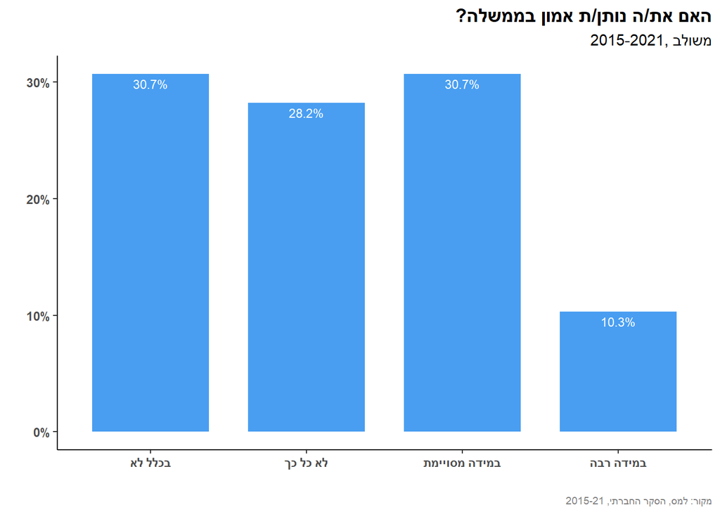

```r
t1<-lss_total%>%
  drop_na(trust_in_gov)%>%
  group_by(trust_in_gov)%>%
  summarize(n=n())%>%
mutate(freq=(n/sum(n))%>%round(3))%>%
  mutate(freq.lab=str_c(100*freq,"%"))

t1%>%
  drop_na(trust_in_gov)%>%
  ggplot(aes(x=factor(trust_in_gov),y=freq*100))+geom_col(width=0.75,alpha=0.8,fill="dodgerblue2")+
  geom_text(aes(label=freq.lab),colour="white",vjust=1.5,size=3)+
  scale_x_discrete(breaks=c("1","2","3","4"),
        labels=c("בכלל לא",
                 "לא כל כך",
                 "במידה מסויימת",
                 "במידה רבה"))+
  labs(title="?האם את/ה נותן/ת אמון בממשלה",
       subtitle = "2015-2021, משולב",
       x="",
       y="",
       color="",
       shape="",
       caption = "מקור: למס, הסקר החברתי, 2015-21")+
    scale_y_continuous(
    labels = scales::percent_format(scale = 1)
  )+
  scale_color_viridis_d()+
  theme_classic()+
  theme(plot.title = element_text(hjust = 1,face="bold"),
  plot.subtitle = element_text(hjust = 1),
  plot.caption = element_text(hjust = 1,color = "gray50",size=7),
  axis.text = element_text(face="bold")
  )
```

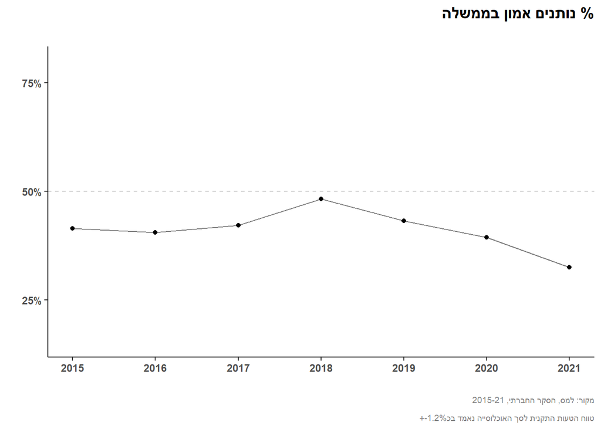

```r
lss_total%>%
  drop_na(trust_in_gov)%>%
  ggplot(aes(x=year,y=(trust_in_gov_bi*100)))+
  stat_summary(geom="point",fun.data=mean_cl_boot)+
    stat_summary(geom="line",fun.data=mean_cl_boot,alpha=0.5)+
  labs(title="נותנים אמון בממשלה %",
       subtitle = "",
       x="",
       y="",
       color="",
       shape="",
       caption = "מקור: למס, הסקר החברתי, 2015-21\n
       +-טווח הטעות התקנית לסך האוכלוסייה נאמד בכ1.2%")+
  geom_hline(yintercept = 50,linetype="dashed",color="gray80")+
    scale_y_continuous(
    labels = scales::percent_format(scale = 1),
    breaks = c(25, 50,75)
  )+
    scale_x_continuous(
    breaks = 2015:2021
  )+
  theme_classic()+
  theme(plot.title = element_text(hjust = 1,face="bold"),
  plot.subtitle = element_text(hjust = 1),
  plot.caption = element_text(hjust = 1,color = "gray50",size=7),
  axis.text = element_text(face="bold")
  )+
  coord_cartesian(ylim=c(15,80))
```

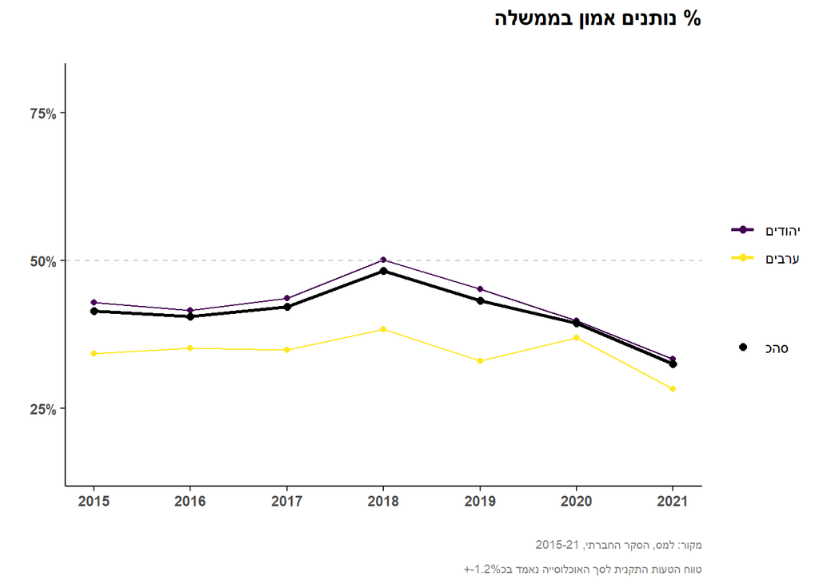

```r
lss_total%>%
  ggplot(aes(x=year,y=trust_in_gov_bi*100,color=factor(arab)))+
  stat_summary(geom="point",fun.data=mean_cl_boot)+
  stat_summary(geom="line",fun.data=mean_cl_boot)+
  stat_summary(aes(group=1,shape="סהכ"),geom="point",fun.data=mean_cl_boot,size=2)+
  stat_summary(aes(group=1,shape="סהכ"),geom="line",fun.data=mean_cl_boot,size=1)+
  labs(title="נותנים אמון בממשלה %",
       subtitle = "",
       x="",
       y="",
       color="",
       shape="",
       caption = "מקור: למס, הסקר החברתי, 2015-21\n
       +-טווח הטעות התקנית לסך האוכלוסייה נאמד בכ1.2%")+
  scale_color_viridis_d(labels=c('יהודים',
                                 'ערבים'))+
  geom_hline(yintercept = 50,linetype="dashed",color="gray80")+
    scale_y_continuous(
    labels = scales::percent_format(scale = 1),
    breaks = c(25, 50,75)
  )+
    scale_x_continuous(
    breaks = 2015:2021
  )+
  theme_classic()+
  theme(plot.title = element_text(hjust = 1,face="bold"),
  plot.subtitle = element_text(hjust = 1),
  plot.caption = element_text(hjust = 1,color = "gray50",size=7),
  axis.text = element_text(face="bold")
  )+
  coord_cartesian(ylim=c(15,80))
```

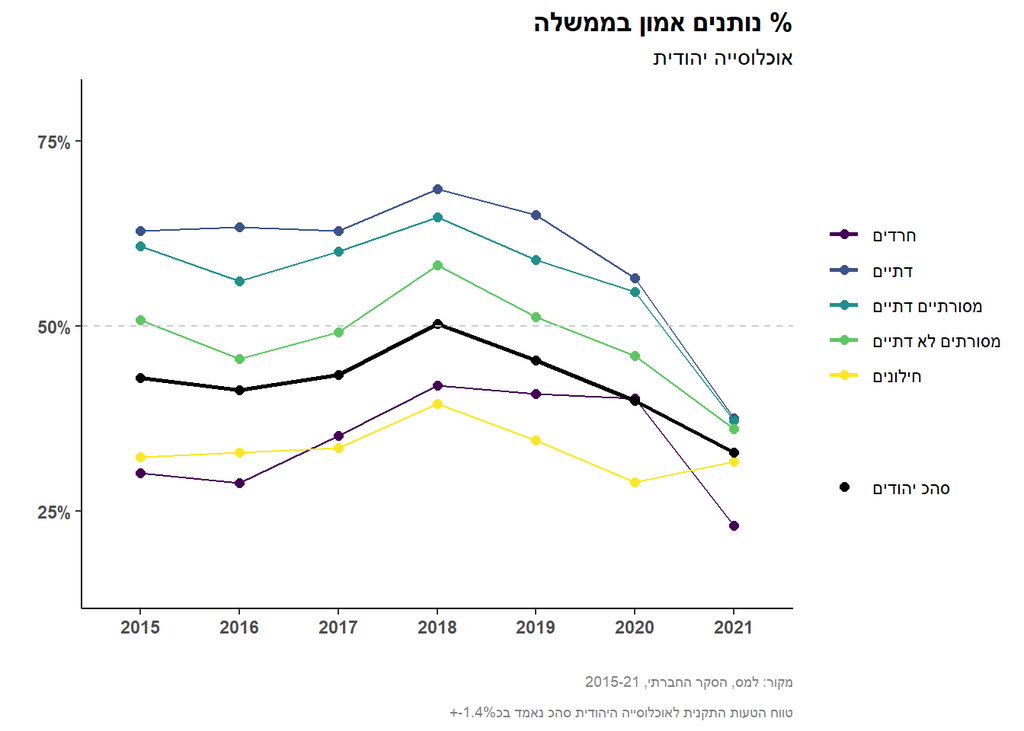

```r
lss_total%>%
  filter(datiut_yehudi<=5)%>%
  ggplot(aes(x=factor(year),y=trust_in_gov_bi*100,color=religiosity_level_jews,group=religiosity_level_jews))+
  stat_summary(geom="point",fun.data=mean_cl_boot,size=2)+
  stat_summary(geom="line",fun.data=mean_cl_boot,size=0.5)+
  stat_summary(aes(group=1,shape="סהכ יהודים"),geom="point",fun.data=mean_cl_boot,size=2)+
  stat_summary(aes(group=1,shape="סהכ יהודים"),geom="line",fun.data=mean_cl_boot,size=1)+
  labs(title="נותנים אמון בממשלה %",
       subtitle = "אוכלוסייה יהודית",
       x="",
       y="",
       color="",
       shape="",
       caption = "מקור: למס, הסקר החברתי, 2015-21\n
       +-טווח הטעות התקנית לאוכלוסייה היהודית סהכ נאמד בכ1.4%")+
  scale_color_viridis_d(labels=c('חרדים',
                                 'דתיים',
                                 'מסורתיים דתיים',
                                 'מסורתים לא דתיים',
                                 'חילונים'))+
  geom_hline(yintercept = 50,linetype="dashed",color="gray80")+
  scale_y_continuous(
    labels = scales::percent_format(scale = 1),
    breaks = c(25, 50,75)
  )+
  theme_classic()+
  theme(plot.title = element_text(hjust = 1,face="bold"),
  plot.subtitle = element_text(hjust = 1),
  plot.caption = element_text(hjust = 1,color = "gray50",size=7),
  axis.text = element_text(face="bold")
  )+
  coord_cartesian(ylim=c(15,80))
```

## **Trust in the judiciary system:**

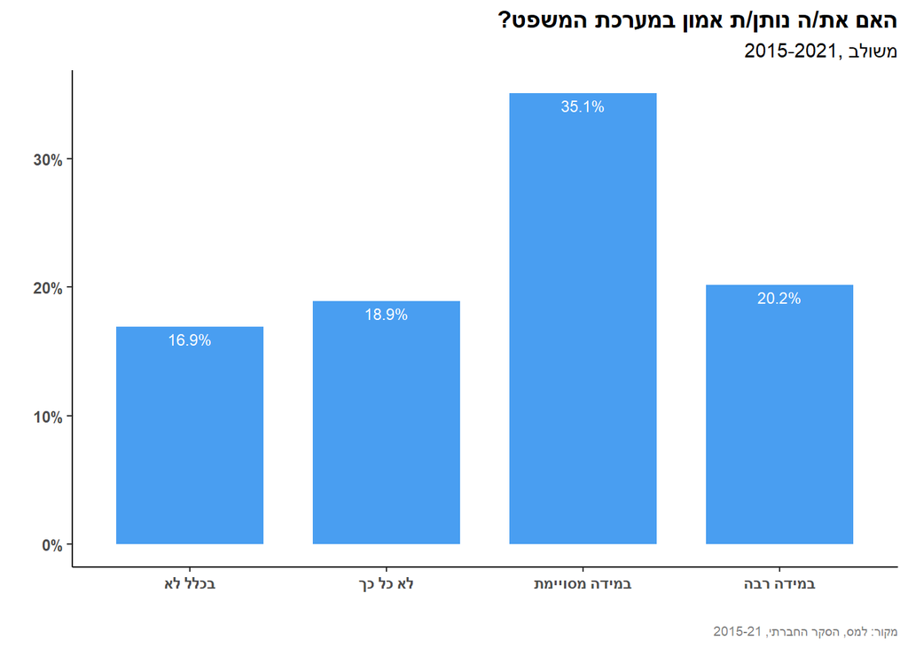

```r
t1<-lss_total%>%
  group_by(trust_in_judiciary)%>%
  summarize(n=n())%>%
  mutate(freq=(n/sum(n))%>%round(3))%>%
  mutate(freq.lab=str_c(100*freq,"%"))


t1%>%
  drop_na(trust_in_judiciary)%>%
  ggplot(aes(x=factor(trust_in_judiciary),y=freq*100))+geom_col(width=0.75,alpha=0.8,fill="dodgerblue2")+
  geom_text(aes(label=freq.lab),colour="white",vjust=1.5,size=3)+
  scale_x_discrete(breaks=c("1","2","3","4"),
        labels=c("בכלל לא",
                 "לא כל כך",
                 "במידה מסויימת",
                 "במידה רבה"))+
  labs(title="?האם את/ה נותן/ת אמון במערכת המשפט",
       subtitle = "2015-2021, משולב",
       x="",
       y="",
       color="",
       shape="",
       caption = "מקור: למס, הסקר החברתי, 2015-21")+
    scale_y_continuous(
    labels = scales::percent_format(scale = 1)
  )+
  scale_color_viridis_d()+
  theme_classic()+
  theme(plot.title = element_text(hjust = 1,face="bold"),
  plot.subtitle = element_text(hjust = 1),
  plot.caption = element_text(hjust = 1,color = "gray50",size=7),
  axis.text = element_text(face="bold")
  )
```

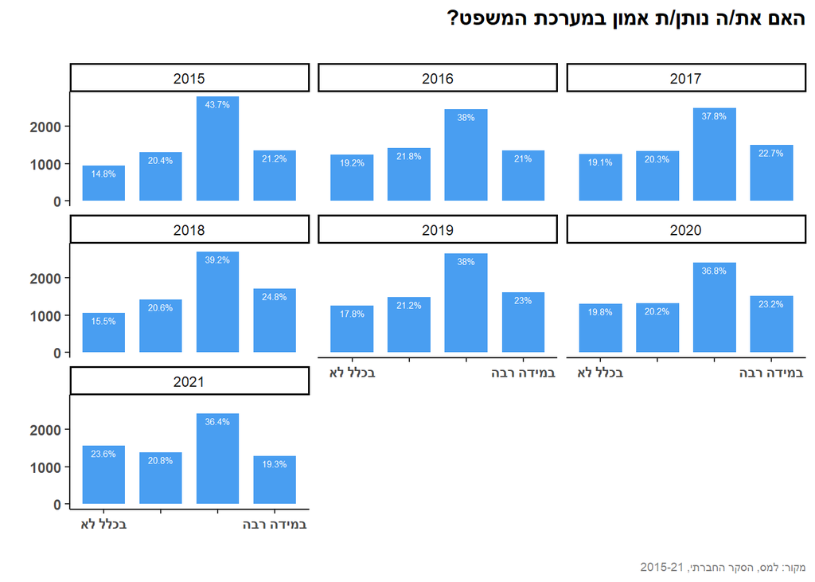

```r
t10<-lss_total%>%
  drop_na(trust_in_judiciary)%>%
  group_by(year,trust_in_judiciary)%>%
  summarize(n=n())%>%
  mutate(freq=(n/sum(n))%>%round(3))%>%
  mutate(freq.lab=str_c(100*freq,"%"))

t10%>%
  drop_na(trust_in_judiciary)%>%
  ggplot(aes(x=factor(trust_in_judiciary),y=n))+
  geom_col(width=0.75,alpha=0.8,fill="dodgerblue2")+
  geom_text(aes(label=freq.lab),colour="white",vjust=1.5,size=2)+
  scale_x_discrete(breaks=c("1","2","3","4"),
        labels=c("בכלל לא",
                 "",
                 "",
                 "במידה רבה"))+
  labs(title="?האם את/ה נותן/ת אמון במערכת המשפט",
       subtitle = "",
       x="",
       y="",
       color="",
       shape="",
       caption = "מקור: למס, הסקר החברתי, 2015-21")+
  facet_wrap(vars(year))+
  scale_color_viridis_d()+
  theme_classic()+
  theme(plot.title = element_text(hjust = 1,face="bold"),
  plot.subtitle = element_text(hjust = 1),
  plot.caption = element_text(hjust = 1,color = "gray50",size=7),
  axis.text = element_text(face="bold")
  )
```

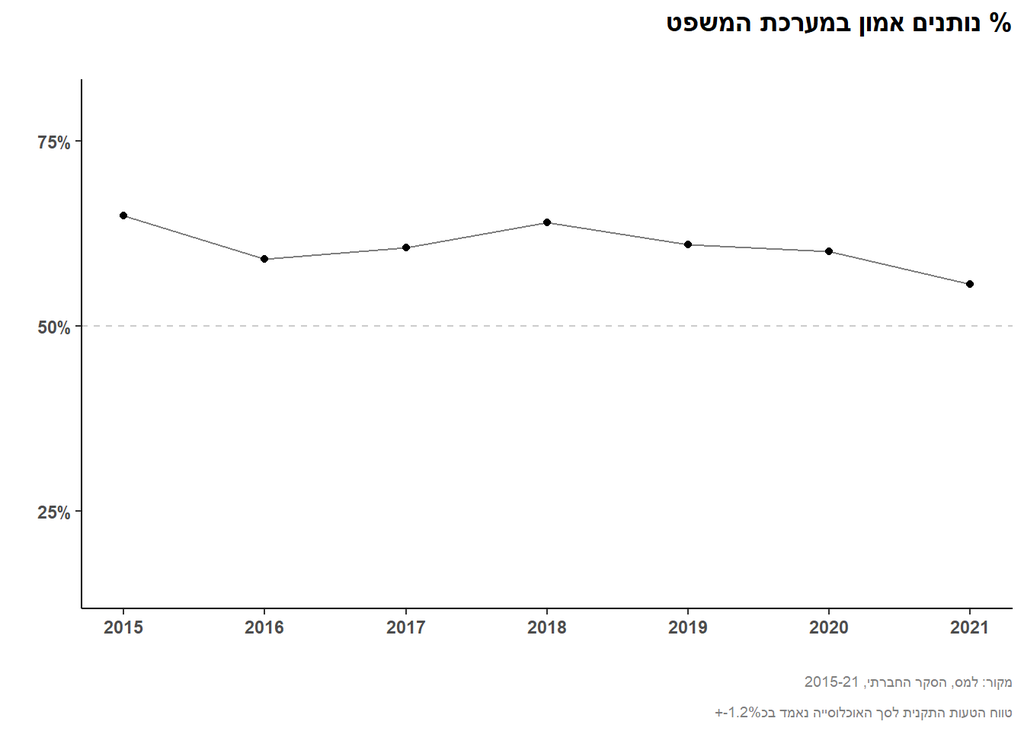

```r
lss_total%>%
  ggplot(aes(x=year,y=(trust_in_judiciary_bi*100)))+
  stat_summary(geom="point",fun.data=mean_cl_boot)+
    stat_summary(geom="line",fun.data=mean_cl_boot,alpha=0.5)+
  labs(title="נותנים אמון במערכת המשפט %",
       subtitle = "",
       x="",
       y="",
       color="",
       shape="",
       caption = "מקור: למס, הסקר החברתי, 2015-21\n
       +-טווח הטעות התקנית לסך האוכלוסייה נאמד בכ1.2%")+
  geom_hline(yintercept = 50,linetype="dashed",color="gray80")+
    scale_y_continuous(
    labels = scales::percent_format(scale = 1),
    breaks = c(25, 50,75)
  )+
    scale_x_continuous(
    breaks = 2015:2021
  )+
  theme_classic()+
  theme(plot.title = element_text(hjust = 1,face="bold"),
  plot.subtitle = element_text(hjust = 1),
  plot.caption = element_text(hjust = 1,color = "gray50",size=7),
  axis.text = element_text(face="bold")
  )+
  coord_cartesian(ylim=c(15,80))
```

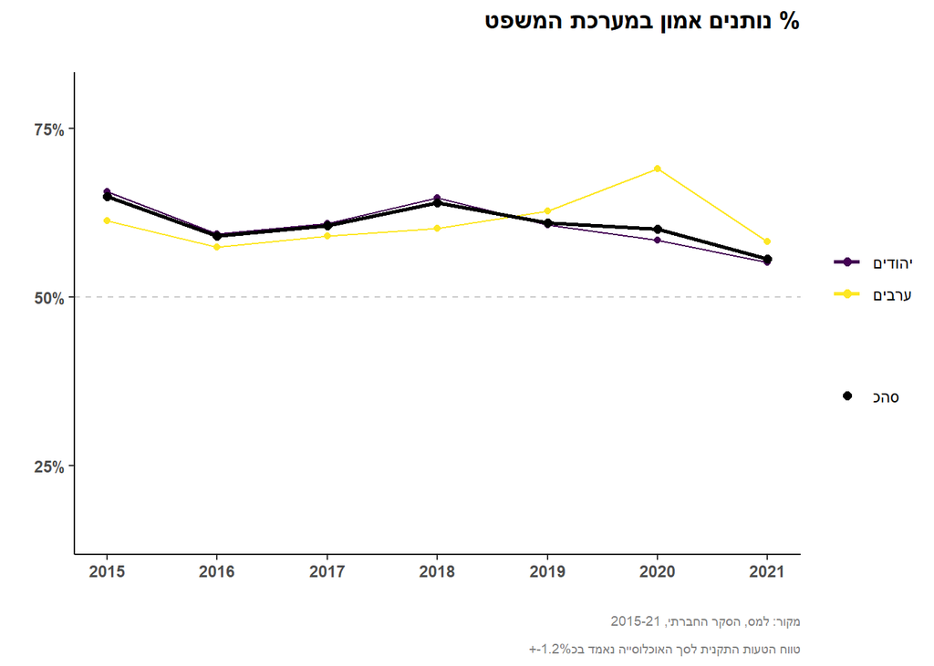

```r
lss_total%>%
  ggplot(aes(x=year,y=trust_in_judiciary_bi*100,color=factor(arab)))+
  stat_summary(geom="point",fun.data=mean_cl_boot)+
  stat_summary(geom="line",fun.data=mean_cl_boot)+
  stat_summary(aes(group=1,shape="סהכ"),geom="point",fun.data=mean_cl_boot,size=2)+
  stat_summary(aes(group=1,shape="סהכ"),geom="line",fun.data=mean_cl_boot,size=1)+
  labs(title="נותנים אמון במערכת המשפט %",
       subtitle = "",
       x="",
       y="",
       color="",
       shape="",
       caption = "מקור: למס, הסקר החברתי, 2015-21\n
       +-טווח הטעות התקנית לסך האוכלוסייה נאמד בכ1.2%")+
   scale_color_viridis_d(labels=c('יהודים',
                                 'ערבים'))+
  geom_hline(yintercept = 50,linetype="dashed",color="gray80")+
    scale_y_continuous(
    labels = scales::percent_format(scale = 1),
    breaks = c(25, 50,75)
  )+
    scale_x_continuous(
    breaks = 2015:2021
  )+
  theme_classic()+
  theme(plot.title = element_text(hjust = 1,face="bold"),
  plot.subtitle = element_text(hjust = 1),
  plot.caption = element_text(hjust = 1,color = "gray50",size=7),
  axis.text = element_text(face="bold")
  )+
  coord_cartesian(ylim=c(15,80))
```

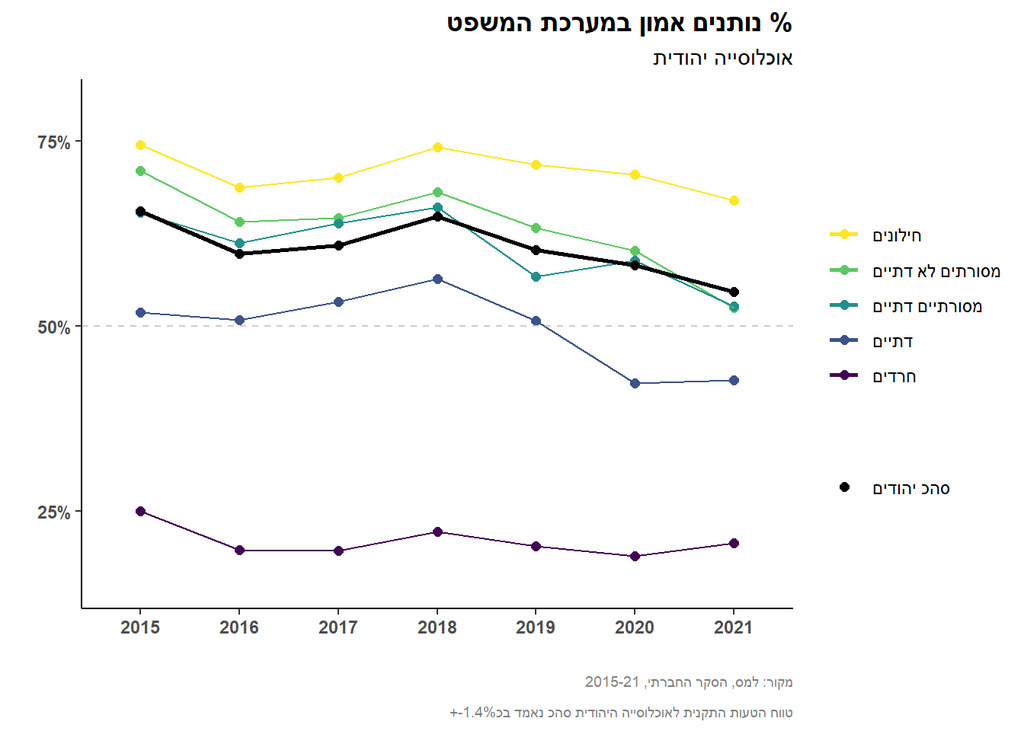

```r
t1 <- lss_total

t1$religiosity_level_jews <- factor(t1$religiosity_level_jews,
                                    levels = c("5. Hilony",
                                               "4. Masorty lo col cah dati",
                                               "3. Masorty dati",
                                               "2. Dati",
                                               "1. Haredi"))

p2 <- t1%>%
  filter(datiut_yehudi<=5)%>%
  ggplot(aes(x=factor(year),y=trust_in_judiciary_bi*100,color=religiosity_level_jews,group=religiosity_level_jews))+
  stat_summary(geom="point",fun.data=mean_cl_boot,size=2)+
  stat_summary(geom="line",fun.data=mean_cl_boot,size=0.5)+
  stat_summary(aes(group=1,shape="סהכ יהודים"),geom="point",fun.data=mean_cl_boot,size=2)+
  stat_summary(aes(group=1,shape="סהכ יהודים"),geom="line",fun.data=mean_cl_boot,size=1)+
  labs(title="נותנים אמון במערכת המשפט %",
       subtitle = "אוכלוסייה יהודית",
       x="",
       y="",
       color="",
       shape="",
       caption = "מקור: למס, הסקר החברתי, 2015-21\n
       +-טווח הטעות התקנית לאוכלוסייה היהודית סהכ נאמד בכ1.4%")+
  scale_color_viridis_d(begin = 1,end=0,labels=c('חילונים',
                                 'מסורתים לא דתיים',
                                 'מסורתיים דתיים',
                                 'דתיים',
                                 'חרדים'))+
  geom_hline(yintercept = 50,linetype="dashed",color="gray80")+
  scale_y_continuous(
    labels = scales::percent_format(scale = 1),
    breaks = c(25, 50,75)
  )+
  theme_classic()+
  theme(plot.title = element_text(hjust = 1,face="bold"),
  plot.subtitle = element_text(hjust = 1),
  plot.caption = element_text(hjust = 1,color = "gray50",size=7),
  axis.text = element_text(face="bold")
  )+
  coord_cartesian(ylim=c(15,80))

p2
```

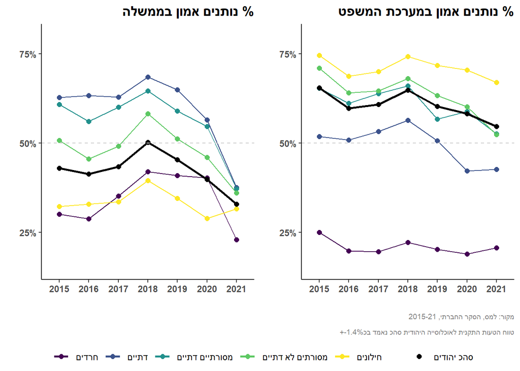

```r
p1 <- lss_total%>%
  filter(datiut_yehudi<=5)%>%
  ggplot(aes(x=factor(year),y=trust_in_gov_bi*100,color=religiosity_level_jews,group=religiosity_level_jews))+
  stat_summary(geom="point",fun.data=mean_cl_boot,size=2)+
  stat_summary(geom="line",fun.data=mean_cl_boot,size=0.5)+
  stat_summary(aes(group=1,shape="סהכ יהודים"),geom="point",fun.data=mean_cl_boot,size=2)+
  stat_summary(aes(group=1,shape="סהכ יהודים"),geom="line",fun.data=mean_cl_boot,size=1)+
  labs(title="נותנים אמון בממשלה %",
       x="",
       y="",
       color="",
       shape="",
       caption = "\n
       ")+
scale_color_viridis_d(labels=c('חרדים',
                                 'דתיים',
                                 'מסורתיים דתיים',
                                 'מסורתים לא דתיים',
                                 'חילונים'))+
  geom_hline(yintercept = 50,linetype="dashed",color="gray80")+
  scale_y_continuous(
    labels = scales::percent_format(scale = 1),
    breaks = c(25, 50,75)
  )+
  theme_classic()+
  theme(plot.title = element_text(hjust = 1,face="bold"),
  plot.subtitle = element_text(hjust = 1),
  plot.caption = element_text(hjust = 1,color = "gray50",size=7),
  axis.text = element_text(face="bold")
  )+
  coord_cartesian(ylim=c(15,80))

t1 <- lss_total

t1$religiosity_level_jews <- factor(t1$religiosity_level_jews,
                                    levels = c("5. Hilony",
                                               "4. Masorty lo col cah dati",
                                               "3. Masorty dati",
                                               "2. Dati",
                                               "1. Haredi"))

p2 <- lss_total%>%
  filter(datiut_yehudi<=5)%>%
  ggplot(aes(x=factor(year),y=trust_in_judiciary_bi*100,color=religiosity_level_jews,group=religiosity_level_jews))+
  stat_summary(geom="point",fun.data=mean_cl_boot,size=2)+
  stat_summary(geom="line",fun.data=mean_cl_boot,size=0.5)+
  stat_summary(aes(group=1,shape="סהכ יהודים"),geom="point",fun.data=mean_cl_boot,size=2)+
  stat_summary(aes(group=1,shape="סהכ יהודים"),geom="line",fun.data=mean_cl_boot,size=1)+
  labs(title="נותנים אמון במערכת המשפט %",
       x="",
       y="",
       color="",
       shape="",
       caption = "מקור: למס, הסקר החברתי, 2015-21\n
       +-טווח הטעות התקנית לאוכלוסייה היהודית סהכ נאמד בכ1.4%")+
  scale_color_viridis_d(labels=c('חילונים',
                                 'מסורתים לא דתיים',
                                 'מסורתיים דתיים',
                                 'דתיים',
                                 'חרדים'))+
  geom_hline(yintercept = 50,linetype="dashed",color="gray80")+
  scale_y_continuous(
    labels = scales::percent_format(scale = 1),
    breaks = c(25, 50,75)
  )+
  theme_classic()+
  theme(plot.title = element_text(hjust = 1,face="bold"),
  plot.subtitle = element_text(hjust = 1),
  plot.caption = element_text(hjust = 1,color = "gray50",size=7),
  axis.text = element_text(face="bold")
  )+
  coord_cartesian(ylim=c(15,80))


ggpubr:: ggarrange(p1,p2,
                   ncol=2,nrow=1,
                   common.legend = T,
                   legend = "bottom")
```

## Weighted analyses

### Trust in Government

weighted (with `srvyr`)

```r
library(srvyr)

lss_total_srvyr <- lss_total %>% as_survey_design(weights = nn)
```

```r
t1 <- lss_total_srvyr %>%
    drop_na(trust_in_gov)%>%
  group_by(trust_in_gov)%>%
  summarize(n=n(),
            proportion_weighted = survey_mean(),
            total_weighted = survey_total())%>%
mutate(freq_unweighted=(n/sum(n)))%>%
  mutate(proportion_weighted.lab=str_c(round(100*proportion_weighted,1),"%"))

t1
```

```
# A tibble: 4 × 8
  trust_in_gov     n proportion_weighted propo…¹ total…² total…³ freq_…⁴ propo…⁵
         <dbl> <int>               <dbl>   <dbl>   <dbl>   <dbl>   <dbl> <chr>
1            1 14845               0.307 0.00219  1.14e7  83292.   0.307 30.7%
2            2 13668               0.283 0.00214  1.05e7  81515.   0.282 28.3%
3            3 14883               0.307 0.00218  1.14e7  83015.   0.307 30.7%
4            4  5008               0.103 0.00144  3.84e6  53937.   0.103 10.3%
# … with abbreviated variable names ¹proportion_weighted_se, ²total_weighted,
#   ³total_weighted_se, ⁴freq_unweighted, ⁵proportion_weighted.lab
```

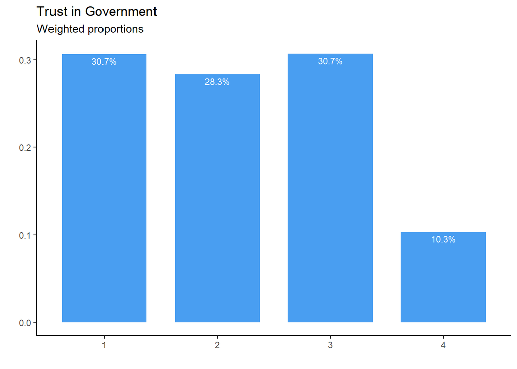

```r
t1%>%
  drop_na(trust_in_gov)%>%
  ggplot(aes(x=factor(trust_in_gov),y=proportion_weighted))+geom_col(width=0.75,alpha=0.8,fill="dodgerblue2")+
  geom_text(aes(label=proportion_weighted.lab),colour="white",vjust=1.5,size=3)+
  labs(title="Trust in Government",subtitle = "Weighted proportions",x="",y="")+
  scale_color_viridis_d()+
  theme_classic()
```

```r
t1 <- lss_total_srvyr %>%
  drop_na(trust_in_gov_bi) %>%
  group_by(year)%>%
  summarize(mean_trust_weighted = survey_mean(trust_in_gov_bi, vartype = "ci"),
            mean_trust_unweighted = mean(trust_in_gov_bi)) %>%
  mutate(ci=mean_trust_weighted-mean_trust_weighted_low)

t1
```

```
# A tibble: 7 × 6
   year mean_trust_weighted mean_trust_weighted_low mean_trust_…¹ mean_…²     ci
  <dbl>               <dbl>                   <dbl>         <dbl>   <dbl>  <dbl>
1  2015               0.414                   0.402         0.426   0.414 0.0123
2  2016               0.406                   0.393         0.418   0.405 0.0122
3  2017               0.420                   0.408         0.432   0.421 0.0121
4  2018               0.482                   0.470         0.494   0.483 0.0121
5  2019               0.430                   0.418         0.442   0.431 0.0118
6  2020               0.398                   0.386         0.410   0.394 0.0122
7  2021               0.325                   0.313         0.336   0.324 0.0115
# … with abbreviated variable names ¹mean_trust_weighted_upp,
#   ²mean_trust_unweighted
```

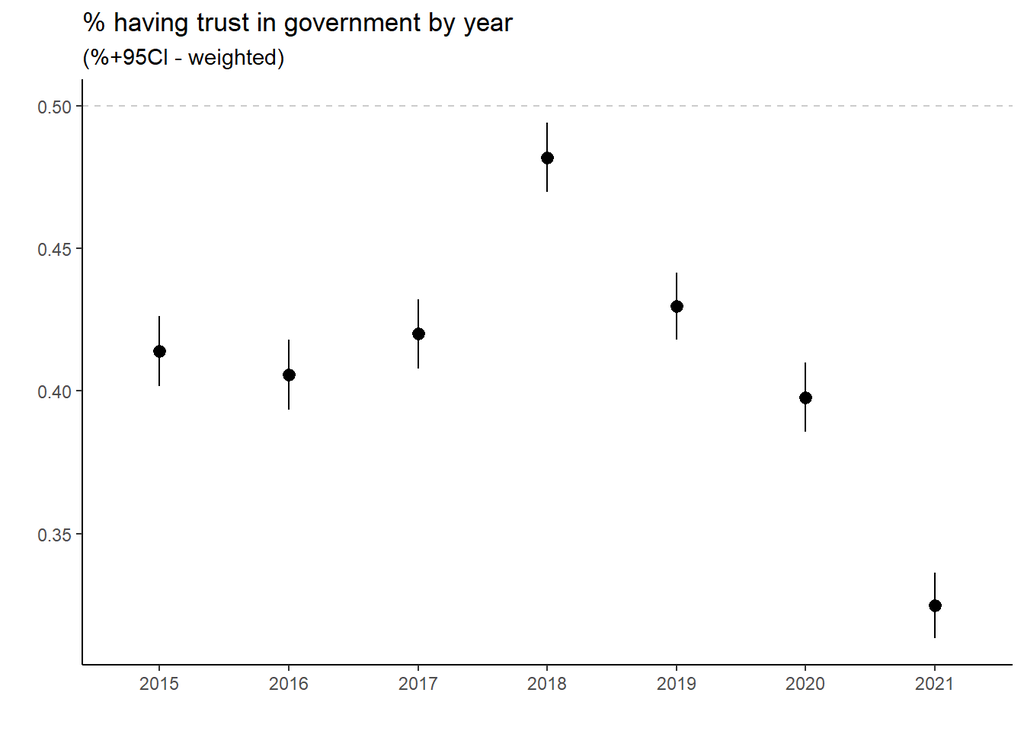

```r
t1%>%
  ggplot(aes(x=factor(year),y=(mean_trust_weighted),ymax = mean_trust_weighted_upp, ymin = mean_trust_weighted_low))+
  geom_point()+
  geom_pointrange()+
  labs(title="% having trust in government by year",subtitle="(%+95CI - weighted)",x="",y="")+
  scale_color_viridis_d()+
  geom_hline(yintercept = 0.5,linetype="dashed",color="gray80")+
  theme_classic()
```

```r
t1 <- lss_total_srvyr %>%
  drop_na(trust_in_gov_bi) %>%
    #filter(datiut_yehudi<=5)%>%
  group_by(year,sector)%>%
  summarize(mean_trust_weighted = survey_mean(trust_in_gov_bi, vartype = "ci"),
            mean_trust_unweighted = mean(trust_in_gov_bi))

t1
```

```
# A tibble: 21 × 6
# Groups:   year [7]
    year sector         mean_trust_weighted mean_trust_weighte…¹ mean_…² mean_…³
   <dbl> <chr>                        <dbl>                <dbl>   <dbl>   <dbl>
 1  2015 arab                         0.316                0.286   0.345   0.342
 2  2015 general                      0.446                0.432   0.460   0.441
 3  2015 ultra_orthodox               0.299                0.257   0.340   0.301
 4  2016 arab                         0.352                0.322   0.381   0.351
 5  2016 general                      0.428                0.414   0.442   0.430
 6  2016 ultra_orthodox               0.290                0.250   0.329   0.288
 7  2017 arab                         0.333                0.304   0.362   0.349
 8  2017 general                      0.444                0.430   0.458   0.445
 9  2017 ultra_orthodox               0.360                0.318   0.401   0.352
10  2018 arab                         0.364                0.332   0.396   0.383
# … with 11 more rows, and abbreviated variable names ¹mean_trust_weighted_low,
#   ²mean_trust_weighted_upp, ³mean_trust_unweighted
```

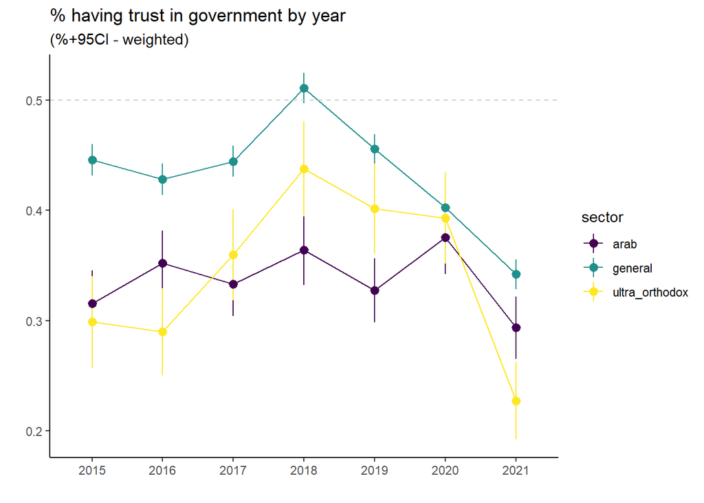

```r
t1%>%
  ggplot(aes(x=factor(year),y=(mean_trust_weighted),ymax = mean_trust_weighted_upp, ymin = mean_trust_weighted_low,color=sector))+
  geom_point()+
  geom_pointrange()+
  geom_line(aes(group=sector))+
  labs(title="% having trust in government by year",subtitle="(%+95CI - weighted)",x="",y="")+
  scale_color_viridis_d()+
  geom_hline(yintercept = 0.5,linetype="dashed",color="gray80")+
  theme_classic()
```

```r
t1 <- lss_total_srvyr %>%
  drop_na(trust_in_gov_bi) %>%
    filter(datiut_yehudi<=5)%>%
  group_by(year,religiosity_level_jews)%>%
  summarize(mean_trust_weighted = survey_mean(trust_in_gov_bi, vartype = "ci"),
            mean_trust_unweighted = mean(trust_in_gov_bi))

t1
```

```
# A tibble: 35 × 6
# Groups:   year [7]
    year religiosity_level_jews     mean_trust_weighted mean_t…¹ mean_…² mean_…³
   <dbl> <chr>                                    <dbl>    <dbl>   <dbl>   <dbl>
 1  2015 1. Haredi                                0.299    0.257   0.340   0.301
 2  2015 2. Dati                                  0.623    0.582   0.665   0.628
 3  2015 3. Masorty dati                          0.602    0.562   0.642   0.608
 4  2015 4. Masorty lo col cah dati               0.514    0.486   0.542   0.507
 5  2015 5. Hilony                                0.325    0.306   0.345   0.323
 6  2016 1. Haredi                                0.290    0.250   0.329   0.288
 7  2016 2. Dati                                  0.632    0.591   0.673   0.633
 8  2016 3. Masorty dati                          0.562    0.522   0.601   0.561
 9  2016 4. Masorty lo col cah dati               0.452    0.422   0.482   0.456
10  2016 5. Hilony                                0.324    0.304   0.343   0.329
# … with 25 more rows, and abbreviated variable names ¹mean_trust_weighted_low,
#   ²mean_trust_weighted_upp, ³mean_trust_unweighted
```

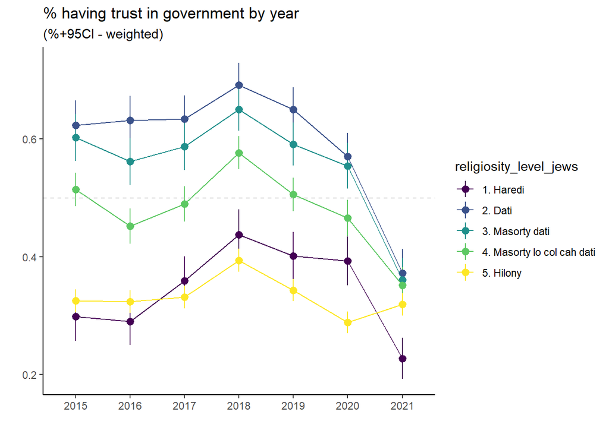

```r
t1%>%
  ggplot(aes(x=factor(year),y=(mean_trust_weighted),ymax = mean_trust_weighted_upp, ymin = mean_trust_weighted_low,color=religiosity_level_jews))+
  geom_point()+
  geom_pointrange()+
  geom_line(aes(group=religiosity_level_jews))+
  labs(title="% having trust in government by year",subtitle="(%+95CI - weighted)",x="",y="")+
  scale_color_viridis_d()+
  geom_hline(yintercept = 0.5,linetype="dashed",color="gray80")+
  theme_classic()
```

### Trust in Judicary

```r
t1 <- lss_total_srvyr %>%
  group_by(trust_in_judiciary)%>%
  summarize(n=n(),
            proportion_weighted = survey_mean(),
            total_weighted = survey_total())%>%
mutate(freq_unweighted=(n/sum(n)))%>%
  mutate(proportion_weighted.lab=str_c(round(100*proportion_weighted,1),"%"))

t1
```

```
# A tibble: 5 × 8
  trust_in_judiciary     n proportion_…¹ propo…² total…³ total…⁴ freq_…⁵ propo…⁶
               <dbl> <int>         <dbl>   <dbl>   <dbl>   <dbl>   <dbl> <chr>
1                  1  8618        0.170  0.00174  6.64e6  68556.  0.169  17%
2                  2  9658        0.190  0.00182  7.44e6  71961.  0.189  19%
3                  3 17928        0.352  0.00221  1.37e7  88169.  0.351  35.2%
4                  4 10316        0.202  0.00185  7.89e6  72955.  0.202  20.2%
5                 NA  4524        0.0856 0.00128  3.34e6  50282.  0.0886 8.6%
# … with abbreviated variable names ¹proportion_weighted,
#   ²proportion_weighted_se, ³total_weighted, ⁴total_weighted_se,
#   ⁵freq_unweighted, ⁶proportion_weighted.lab
```

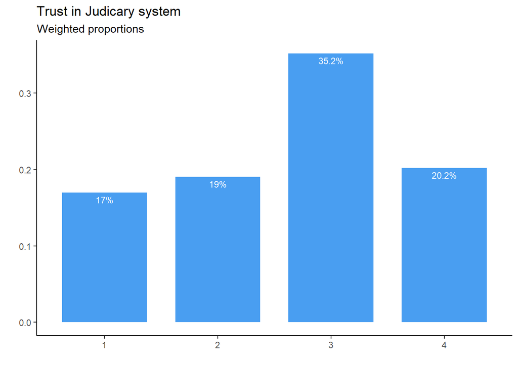

```r
t1%>%
  drop_na(trust_in_judiciary)%>%
  ggplot(aes(x=factor(trust_in_judiciary),y=proportion_weighted))+geom_col(width=0.75,alpha=0.8,fill="dodgerblue2")+
  geom_text(aes(label=proportion_weighted.lab),colour="white",vjust=1.5,size=3)+
  labs(title="Trust in Judicary system",subtitle = "Weighted proportions",x="",y="")+
  theme_classic()
```

```r
t1 <- lss_total_srvyr %>%
  drop_na(trust_in_judiciary_bi) %>%
  group_by(year,sector)%>%
  summarize(mean_trust_weighted = survey_mean(trust_in_judiciary_bi, vartype = "ci"),
            mean_trust_unweighted = mean(trust_in_judiciary_bi)) %>%
  mutate(mean_trust_weighted-mean_trust_weighted_low)

t1
```

```
# A tibble: 21 × 7
# Groups:   year [7]
    year sector         mean_trust_weighted mean_trust…¹ mean_…² mean_…³ mean_…⁴
   <dbl> <chr>                        <dbl>        <dbl>   <dbl>   <dbl>   <dbl>
 1  2015 arab                         0.576        0.543   0.609   0.612  0.0333
 2  2015 general                      0.694        0.681   0.708   0.697  0.0135
 3  2015 ultra_orthodox               0.244        0.204   0.284   0.249  0.0399
 4  2016 arab                         0.573        0.543   0.604   0.574  0.0305
 5  2016 general                      0.633        0.619   0.648   0.637  0.0141
 6  2016 ultra_orthodox               0.206        0.169   0.242   0.198  0.0362
 7  2017 arab                         0.570        0.539   0.602   0.590  0.0315
 8  2017 general                      0.650        0.636   0.664   0.655  0.0139
 9  2017 ultra_orthodox               0.202        0.167   0.237   0.196  0.0348
10  2018 arab                         0.586        0.553   0.619   0.601  0.0329
# … with 11 more rows, and abbreviated variable names ¹mean_trust_weighted_low,
#   ²mean_trust_weighted_upp, ³mean_trust_unweighted,
#   ⁴`mean_trust_weighted - mean_trust_weighted_low`
```

```r
t1 <- lss_total_srvyr %>%
  drop_na(trust_in_judiciary_bi) %>%
  group_by(year)%>%
  summarize(mean_trust_weighted = survey_mean(trust_in_judiciary_bi, vartype = "ci"),
            mean_trust_unweighted = mean(trust_in_judiciary_bi))

t1
```

```
# A tibble: 7 × 5
   year mean_trust_weighted mean_trust_weighted_low mean_trust_weighte…¹ mean_…²
  <dbl>               <dbl>                   <dbl>                <dbl>   <dbl>
1  2015               0.641                   0.629                0.653   0.648
2  2016               0.591                   0.579                0.604   0.590
3  2017               0.600                   0.588                0.613   0.605
4  2018               0.637                   0.625                0.649   0.639
5  2019               0.608                   0.597                0.620   0.610
6  2020               0.606                   0.593                0.618   0.600
7  2021               0.560                   0.548                0.573   0.557
# … with abbreviated variable names ¹mean_trust_weighted_upp,
#   ²mean_trust_unweighted
```

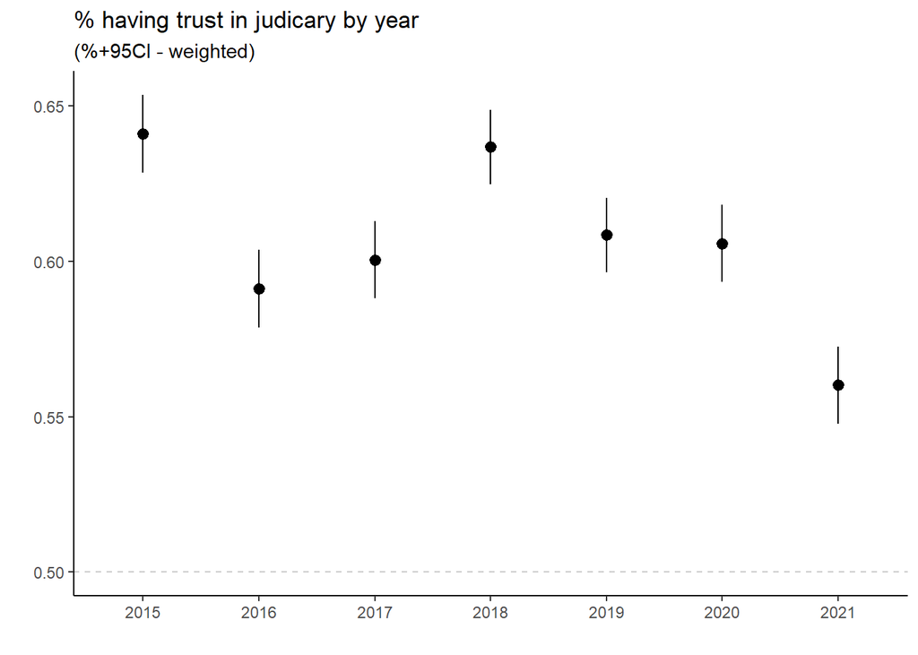

```r
t1%>%
  ggplot(aes(x=factor(year),y=(mean_trust_weighted),ymax = mean_trust_weighted_upp, ymin = mean_trust_weighted_low))+
  geom_point()+
  geom_pointrange()+
  geom_line()+
  labs(title="% having trust in judicary by year",subtitle="(%+95CI - weighted)",x="",y="")+
  scale_color_viridis_d()+
  geom_hline(yintercept = 0.5,linetype="dashed",color="gray80")+
  theme_classic()
```

```r
t1 <- lss_total_srvyr %>%
  drop_na(trust_in_judiciary_bi) %>%
    #filter(datiut_yehudi<=5)%>%
  group_by(year,sector)%>%
  summarize(mean_trust_weighted = survey_mean(trust_in_judiciary_bi, vartype = "ci"),
            mean_trust_unweighted = mean(trust_in_judiciary_bi))

t1
```

```
# A tibble: 21 × 6
# Groups:   year [7]
    year sector         mean_trust_weighted mean_trust_weighte…¹ mean_…² mean_…³
   <dbl> <chr>                        <dbl>                <dbl>   <dbl>   <dbl>
 1  2015 arab                         0.576                0.543   0.609   0.612
 2  2015 general                      0.694                0.681   0.708   0.697
 3  2015 ultra_orthodox               0.244                0.204   0.284   0.249
 4  2016 arab                         0.573                0.543   0.604   0.574
 5  2016 general                      0.633                0.619   0.648   0.637
 6  2016 ultra_orthodox               0.206                0.169   0.242   0.198
 7  2017 arab                         0.570                0.539   0.602   0.590
 8  2017 general                      0.650                0.636   0.664   0.655
 9  2017 ultra_orthodox               0.202                0.167   0.237   0.196
10  2018 arab                         0.586                0.553   0.619   0.601
# … with 11 more rows, and abbreviated variable names ¹mean_trust_weighted_low,
#   ²mean_trust_weighted_upp, ³mean_trust_unweighted
```

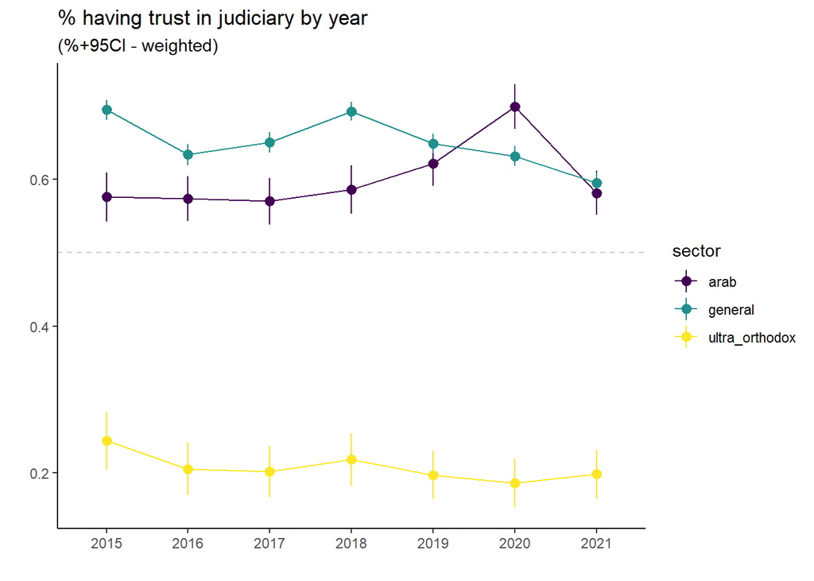

```r
t1%>%
  ggplot(aes(x=factor(year),y=(mean_trust_weighted),ymax = mean_trust_weighted_upp, ymin = mean_trust_weighted_low,color=sector))+
  geom_point()+
  geom_pointrange()+
  geom_line(aes(group=sector))+
  labs(title="% having trust in judiciary by year",subtitle="(%+95CI - weighted)",x="",y="")+
  scale_color_viridis_d()+
  geom_hline(yintercept = 0.5,linetype="dashed",color="gray80")+
  theme_classic()
```

```r
t1 <- lss_total_srvyr %>%
  drop_na(trust_in_judiciary_bi) %>%
    filter(datiut_yehudi<=5)%>%
  group_by(year,religiosity_level_jews)%>%
  summarize(mean_trust_weighted = survey_mean(trust_in_judiciary_bi, vartype = "ci"),
            mean_trust_unweighted = mean(trust_in_judiciary_bi))

t1
```

```
# A tibble: 35 × 6
# Groups:   year [7]
    year religiosity_level_jews     mean_trust_weighted mean_t…¹ mean_…² mean_…³
   <dbl> <chr>                                    <dbl>    <dbl>   <dbl>   <dbl>
 1  2015 1. Haredi                                0.244    0.204   0.284   0.249
 2  2015 2. Dati                                  0.512    0.467   0.556   0.518
 3  2015 3. Masorty dati                          0.645    0.604   0.686   0.653
 4  2015 4. Masorty lo col cah dati               0.708    0.681   0.735   0.709
 5  2015 5. Hilony                                0.747    0.728   0.765   0.745
 6  2016 1. Haredi                                0.206    0.169   0.242   0.198
 7  2016 2. Dati                                  0.511    0.467   0.554   0.508
 8  2016 3. Masorty dati                          0.601    0.560   0.641   0.612
 9  2016 4. Masorty lo col cah dati               0.640    0.611   0.670   0.640
10  2016 5. Hilony                                0.683    0.663   0.703   0.687
# … with 25 more rows, and abbreviated variable names ¹mean_trust_weighted_low,
#   ²mean_trust_weighted_upp, ³mean_trust_unweighted
```

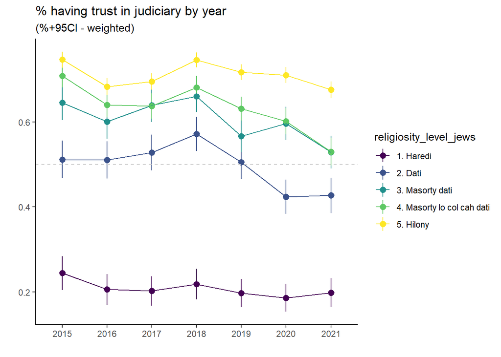

```r
t1%>%
  ggplot(aes(x=factor(year),y=(mean_trust_weighted),ymax = mean_trust_weighted_upp, ymin = mean_trust_weighted_low,color=religiosity_level_jews))+
  geom_point()+
  geom_pointrange()+
  geom_line(aes(group=religiosity_level_jews))+
  labs(title="% having trust in judiciary by year",subtitle="(%+95CI - weighted)",x="",y="")+
  scale_color_viridis_d()+
  geom_hline(yintercept = 0.5,linetype="dashed",color="gray80")+
  theme_classic()
```